# Spread of a disease: Coveying exponential data

5/28/2020

## Introduction

Most of us can’t make intuative sense of an exponential spread but diseases spread exponentially.

A simple depiction of the number of cases of a disease, while easy to understand doesn’t speak much about the severity of the situation.

Multipliers such as R<sub>0</sub> (R-naught) do a better job at describing the spread, but it fails at conveying the idea to general population.

There must be a better way of conveying the facts. Maybe Doubling time?

## Doubling time

### Merits and demerits

**Time for the number of cases to double**

Merits:

- More intuative as larger numbers; means that it takes longer to double. Slower spread
- Represents exponential spread and its severity; better than the number of cases
- Can be calculated on a daily bases (after smoothing, like average of previous week)
- Better at predicting

Demerits:

- Slower to react to decrease in spread than the number of cases
- Prevelance of the disease is not represented
- Not widely adopted; might not be understandable at first glance

## Plot / Map

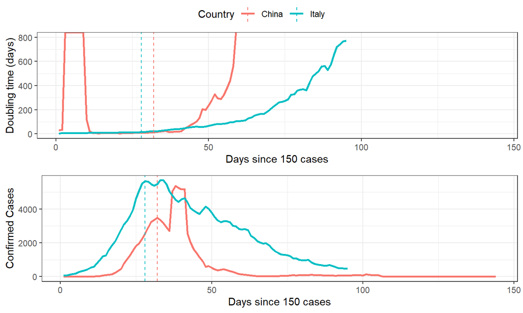

Doubling time of COVID-19 in China and Italy. The vertical lines indicates 2 weeks since announcement of lockdown

- At the start; Few cases but short doubling time
- After Lockdown; Drop in number of cases but doubling time has just started increasing

## Summary

**Early action is more effective than a late reaction**

- Doubling time can convey the severity of an exponential spread
- It can help inform government decisions during few cases
- It does a better job at informing citizens of the severity
- Can help identify countries that are and/or will be at a higher risk

**Source:** *[European Centre for Disease Prevention and Control](https://www.ecdc.europa.eu/en/publications-data/download-todays-data-geographic-distribution-covid-19-cases-worldwide)*

**[Shiny web app: Spread of a disease: Coveying exponential data](http://fernandesv.shinyapps.io/DoublingTimeCOVID19/)**